# Introduction to Simulation of Plant Breeding Programs

Joao Amaro Netto

2026-09-22

## 1 Working with the Simulation Script

The following script brings together the concepts introduced throughout the course and implements complete breeding programs using AlphaSimR. Rather than treating the code as a collection of independent commands, we will use it to represent the flow of a breeding program over generations and calendar years.

The script is organized into sequential sections, following the development of the breeding population from the initial population through selection, advancement, and variety development. We will first establish the genetic population and simulate the burn-in phase, and then use the resulting population as a common starting point for comparing alternative breeding strategies.

Two main breeding pipelines are implemented: a conventional breeding pipeline and a genomic selection pipeline. The script also allows us to examine alternative selection strategies in a clonal breeding program.

The code can be explored interactively. Code blocks can be expanded when you want to inspect the implementation, while outputs can be shown when you want to examine the results. The objective is not only to run the simulation, but to understand how each component of a breeding program is translated into a simulation model.

### 1.1 A simplified and introductory framework

This course provides an introductory approach to the simulation of plant breeding programs. The breeding pipelines implemented here are simplified representations of real breeding programs and are intended primarily to illustrate the principles and concepts involved in breeding program simulation.

Several biological, operational, and statistical aspects of real breeding programs are therefore not explicitly represented. The simulations also have inherent limitations associated with the assumptions, parameters, genetic architecture, population structure, and selection procedures used.

Consequently, the results generated by these simulations should not be interpreted as direct predictions of the performance of a real breeding program. Instead, the simulations should be viewed as a framework for understanding how breeding decisions and program design can influence genetic change over time.

As the concepts introduced in the course become more familiar, more complex simulations can be developed by incorporating additional biological, genetic, environmental, and operational factors.

> **Note.** We use simplified parameters so that the code can run on most computers.

### 1.2 Base Initial Parameters

```r
# AlphasimR

library(AlphaSimR)

# Founder genome
founderGenomes = runMacs(nInd = 10, # Number of individuals that compose the base genome
                         nChr = 10, # Number of chromosome pairs of the target species
                         segSites = 100, # number of segregation sites
                         species = "GENERIC", # Available presets: MAIZE, WHEAT, CATTLE, GENERIC
                         ploidy = 2) # Setting the ploidy

# Object created
founderGenomes
```

```
## An object of class "MapPop"
## Ploidy: 2
## Individuals: 10
## Chromosomes: 10
## Loci: 1000
```

```r
# Genetic map of the segregation sites
founderGenomes@genMap #The positions are in Morgan
```

[output not shown]

[output cut: 288 more lines]

[output not shown]

```r
# Global simulation parameters from founder genomes.
SP = SimParam$new(founderGenomes)

# Additive trait
SP$addTraitA(nQtlPerChr = 15, # Number of QTL per chromosome
             mean = 10,       # Trait mean
             var = 10)        # Trait variance

SP$addSnpChip(nSnpPerChr = 50)

# QTL effects (for the traits)
SP$traits[[1]]@addEff
```

```
##   [1] -0.15855228  0.46294091 -0.59839845 -0.21419352 -0.42549071  0.27404429
##   [7] -0.76193940  0.11925276  0.60224337 -0.20627982  1.79098897  0.02133119
##  [13]  0.22931650  0.11692259  0.36427193  0.64200337  0.81666776  0.13576449
##  [19] -0.41759526  1.00953183  0.21745005 -0.32822545 -0.57567320  0.16387546
##  [25] -0.79927754  0.23285623  0.63356738 -0.40599015 -0.48413309  0.40366125
##  [31]  0.66287847 -0.89185516  0.83940215 -0.30887929  0.39316053 -0.18056144
##  [37]  0.53739592 -1.13098424  0.33125326 -0.87037410  0.45065089  0.21769642
##  [43] -0.63214154  0.09168986  0.69566444 -0.34010800  0.54659624 -0.15020151
##  [49]  1.19165629 -0.13687372  0.64169385 -0.07421334 -0.01258285 -0.13666102
##  [55] -0.86340471 -0.26814109  0.71279375  0.04652087 -0.22986423  0.09841189
##  [61] -0.63863093 -0.80179454 -0.08251754  0.85077666  0.25890068  0.28548086
##  [67]  0.27409962  0.04588969 -0.55571512 -0.10146557  0.89451670  0.06728623
##  [73] -0.14251143 -0.09030382 -0.30438904 -0.02142877 -0.88988853 -0.07172124
##  [79] -0.11170503 -0.34406646 -0.38265220  0.25741096 -0.08370779 -0.27522939
##  [85] -0.23029398  0.65283544  0.53672031 -1.17304867 -0.34313632  0.76781030
##  [91]  0.11159941 -0.16724698  0.70154458 -0.42362443  0.24193624  0.05269953
##  [97] -0.98888416 -0.10274431 -0.92065258 -0.04584504 -1.11468520 -0.02248267
## [103] -0.72435709 -0.44206944  0.44809822 -1.15683691  0.24006114  0.42662252
## [109]  0.07492375 -0.42858982 -0.47332321 -0.34407600 -0.73767395 -0.34690906
## [115]  0.42134013  0.68233893 -0.37124066  0.13590862 -0.23305099  0.24661619
## [121] -0.52864849  0.60496939  0.65559480  0.56219237 -0.67752259 -0.23099487
## [127] -0.57537344 -0.71436996  0.15685402 -0.09555794 -0.55843030 -0.30651677
## [133]  0.46464851 -0.68926171 -0.21286307  0.42408688  0.03306638  0.46233860
## [139] -0.01399731 -0.02671066 -0.29530330 -0.33524294 -0.44363265  0.47011663
## [145] -0.88198579 -0.15211045 -0.41419509 -0.07113916 -0.38171542  0.38308121
```

```r
# Creating individuals/population
basePop = newPop(founderGenomes)

basePop
```

```
## An object of class "Pop"
## Ploidy: 2
## Individuals: 10
## Chromosomes: 10
## Loci: 1000
## Traits: 1
```

```r
# Gen param
genParam(basePop)
```

```
## $varA
##        Trait1
## Trait1     10
##
## $varD
##        Trait1
## Trait1      0
##
## $varAA
##        Trait1
## Trait1      0
##
## $varG
##        Trait1
## Trait1     10
```

[output cut: 472 more lines]

```r
# Check the genotypes
popGeno = pullSegSiteGeno(basePop)
popGeno[, 1:10]
```

```
##    1_1 1_2 1_3 1_4 1_5 1_6 1_7 1_8 1_9 1_10
## 1    0   0   2   0   0   0   2   0   0    0
## 2    1   1   2   0   0   0   1   1   1    0
## 3    2   2   0   0   0   0   2   0   0    0
## 4    2   2   1   0   0   0   1   1   0    0
## 5    1   1   1   0   0   0   1   1   1    0
## 6    2   2   2   0   0   1   2   0   0    0
## 7    2   2   1   0   0   1   0   2   2    1
## 8    1   1   0   2   0   0   2   0   0    0
## 9    2   2   0   1   0   0   1   1   1    0
## 10   1   1   0   1   1   0   2   0   0    0
```

## 2 Crossing and Early Population Development

```r
# Making crosses
# 1. Crossing randomly
F1pop = randCross(pop = basePop, nCrosses = 100)

# 2. Make crosses by a list of individuals
# Making the crossing plan
MatingPlan = data.frame(Parent1 = basePop@id[1:5],
                        Parent2 = basePop@id[6:10])
MatingPlan
```

| Parent1 | Parent2 |
| --- | --- |
| 1 | 6 |
| 2 | 7 |
| 3 | 8 |
| 4 | 9 |
| 5 | 10 |

```r
# Crossing based on the crossing list
F1pop = makeCross(basePop, crossPlan = as.matrix(MatingPlan))

# Checking out the pedigree records out of F1
Pedigree = data.frame(Ind = F1pop@id,
                      Parent1 = F1pop@mother,
                      Parent2 = F1pop@father)

Pedigree
```

| Ind | Parent1 | Parent2 |
| --- | --- | --- |
| 111 | 1 | 6 |
| 112 | 2 | 7 |
| 113 | 3 | 8 |
| 114 | 4 | 9 |
| 115 | 5 | 10 |

```r
# Advancing F1 -> F2
F2pop = self(pop = F1pop, nProgeny = 10)

# Or making DH lines
F2DHpop = makeDH(pop=F1pop, nDH=10) # Doubled Haploids

# Setting phenotype
F2pop = setPheno(F2pop, H2 = 0.2)

cor(F2pop@gv, F2pop@pheno) # Correlation between genetic and phenotypic values
```

```
##           Trait1
## Trait1 0.5485483
```

## 3 The Stages of Lines Breeding Pipeline

```r
# Breeding pipeline
#------------- Year 1
F1pop = randCross(pop = basePop, nCrosses = 45, nProgeny = 20) # Crossing block

#------------- Year 2
DHpop = makeDH(pop = F1pop, nDH = 10) # Doubled Haploids

#------------- Year 3
rowStage    = setPheno(pop = DHpop, H2 = 0.2)
PrelimTrial = selectWithinFam(rowStage, nInd = 10, use = "pheno")

#------------- Year 4
PrelimTrial = setPheno(PrelimTrial, H2 = 0.4)
AdvancTrial = selectInd(PrelimTrial, nInd = 100, use = "pheno") # Preliminary Trial

#------------- Year 5
AdvancTrial = setPheno(AdvancTrial, H2 = 0.4)
EliteTrial  = selectInd(AdvancTrial, nInd = 40, use = "pheno") # Advanced Trial

#------------- Year 6
EliteTrial = setPheno(EliteTrial, H2 = 0.4)
Variety    = selectInd(EliteTrial, nInd = 10, use = "pheno") # Elite Trial

meanG(Variety)
```

```
##   Trait1
## 26.35989
```

```r
varG(Variety)
```

```
##          Trait1
## Trait1 5.569667
```

## 4 Selection Across Cycles

```r
# Looping it

Cycles   = 5
Parents  = Base_Parents = Variety # Saving base Parents

results = data.frame(
  Cycle = integer(),
  MeanG = numeric(),
  VarG  = numeric()
)

for (i in 1:Cycles) {

  #------------- Year 1
  F1pop = randCross(pop = Parents, nCrosses = 50, nProgeny = 20)

  #------------- Year 2
  DHpop = makeDH(pop = F1pop, nDH = 10)

  #------------- Year 3
  rowStage    = setPheno(pop = DHpop, H2 = 0.05)
  PrelimTrial = selectWithinFam(rowStage, nInd = 10, use = "pheno")

  #------------- Year 4
  PrelimTrial = setPheno(PrelimTrial, H2 = 0.1)
  AdvancTrial = selectInd(PrelimTrial, nInd = 100, use = "pheno")

  #------------- Year 5
  AdvancTrial = setPheno(AdvancTrial, H2 = 0.2)
  EliteTrial  = selectInd(AdvancTrial, nInd = 40, use = "pheno")

  #------------- Year 6
  EliteTrial = setPheno(EliteTrial, H2 = 0.4)
  Variety    = selectInd(EliteTrial, nInd = 10, use = "pheno")

  Parents = Variety  # Variety used as parents for next cycle

  # Checking genetic parameters
  cat("Cycle: ", i, "\n")
  cat("Mean of Genetic Values: ", meanG(Variety), "\n")
  cat("Genetic Variance: ", varG(Variety), "\n")

  results = rbind(results, data.frame(
    Cycle = i,
    MeanG = meanG(Variety),
    VarG  = varG(Variety)
  ))
}
```

```
## Cycle:  1
## Mean of Genetic Values:  34.08337
## Genetic Variance:  7.508255
## Cycle:  2
## Mean of Genetic Values:  38.40596
## Genetic Variance:  9.014049
## Cycle:  3
## Mean of Genetic Values:  42.16706
## Genetic Variance:  7.505091
## Cycle:  4
## Mean of Genetic Values:  45.79835
## Genetic Variance:  3.311992
## Cycle:  5
## Mean of Genetic Values:  48.45668
## Genetic Variance:  1.793411
```

## 5 Alternative Pipeline with Higher Heritability

```r
# Alternative pipeline using higher H2
Parents = Base_Parents
results_2 = data.frame(
  Cycle = integer(),
  MeanG = numeric(),
  VarG  = numeric()
)

for (i in 1:Cycles) {

  #------------- Year 1
  F1pop = randCross(pop = Parents, nCrosses = 50, nProgeny = 20)

  #------------- Year 2
  DHpop = makeDH(pop = F1pop, nDH = 10)

  #------------- Year 3
  rowStage    = setPheno(pop = DHpop, H2 = 0.05)
  PrelimTrial = selectWithinFam(rowStage, nInd = 10, use = "pheno")

  #------------- Year 4
  PrelimTrial = setPheno(PrelimTrial, H2 = 0.4)
  AdvancTrial = selectInd(PrelimTrial, nInd = 100, use = "pheno")

  #------------- Year 5
  AdvancTrial = setPheno(AdvancTrial, H2 = 0.6)
  EliteTrial  = selectInd(AdvancTrial, nInd = 40, use = "pheno")

  #------------- Year 6
  EliteTrial = setPheno(EliteTrial, H2 = 0.8)
  Variety    = selectInd(EliteTrial, nInd = 10, use = "pheno")

  Parents = Variety  # Variety used as parents for next cycle

  # Checking genetic parameters
  cat("Mean of Genetic Values: ", meanG(Variety), "\n")
  cat("Genetic Variance: ", varG(Variety), "\n")

  results_2 = rbind(results_2, data.frame(
    Cycle = i,
    MeanG = meanG(Variety),
    VarG  = varG(Variety)
  ))
}
```

```
## Mean of Genetic Values:  34.47026
## Genetic Variance:  2.064901
## Mean of Genetic Values:  40.5927
## Genetic Variance:  1.274001
## Mean of Genetic Values:  44.86057
## Genetic Variance:  1.267493
## Mean of Genetic Values:  47.70739
## Genetic Variance:  0.959123
## Mean of Genetic Values:  50.11667
## Genetic Variance:  1.523451
```

```r
# Adding cycle zero
row_0 = data.frame(
  Cycle = 0,
  MeanG = meanG(Base_Parents),
  Trait1 = varG(Base_Parents)
)

results    = rbind(row_0, results)
results_2 = rbind(row_0, results_2)
rownames(results) = rownames(results_2) = NULL
```

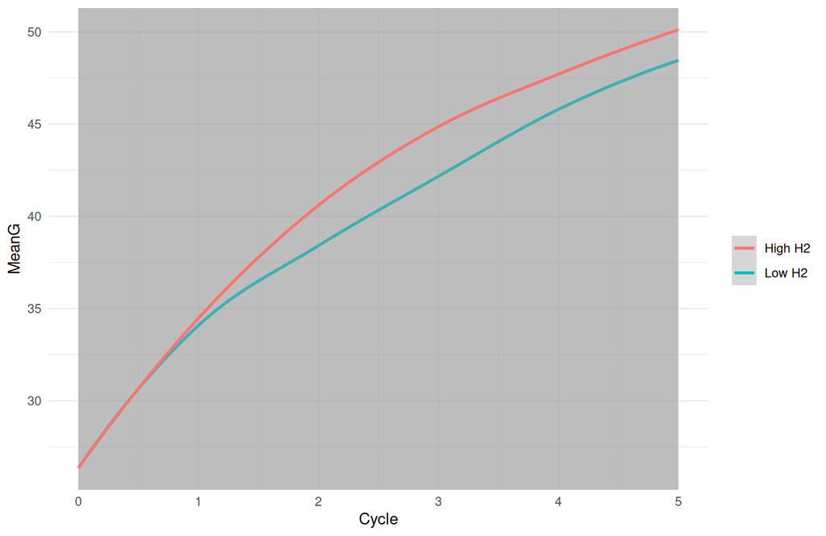

```r
# Plotting results
library(ggplot2)

ggplot() +
  geom_smooth(data = results, aes(x = Cycle, y = MeanG, color = "Low H2"), size = 1) +
  geom_smooth(data = results_2, aes(x = Cycle, y = MeanG, color = "High H2"), size = 1) +
  labs(x = "Cycle", y = "MeanG", color = " ") +
  theme_minimal()
```

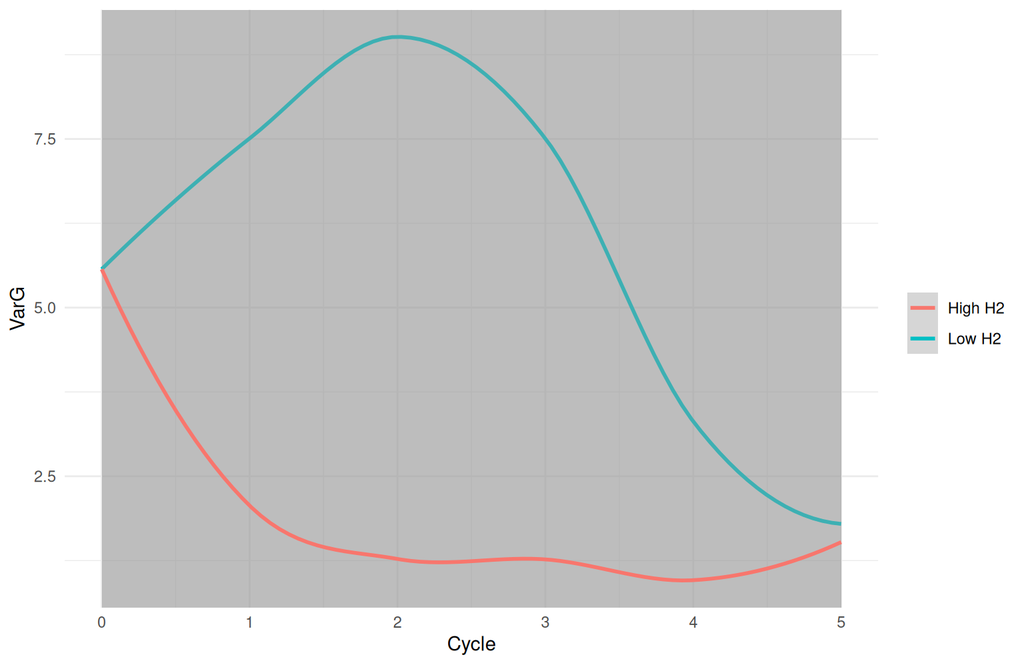

```r
ggplot() +
  geom_smooth(data = results, aes(x = Cycle, y = Trait1, color = "Low H2"), size = 1) +
  geom_smooth(data = results_2, aes(x = Cycle, y = Trait1, color = "High H2"), size = 1) +
  labs(x = "Cycle", y = "VarG", color = " ") +
  theme_minimal()
```

## 6 From Cycles to Years

If we aim to compare different breeding designs and measure by year, not cycles, such as a conventional breeding pipeline versus a GS pipeline, we have to invert the pipeline. To to this, first we have to fill the pipeline. This aims to reproduce the different breeding stages and actions over time, allowing us to evaluate and compare the outcomes of competing strategies across multiple years.

```r
#Filling the pipeline

Parents = basePop
trials = 6
for(trial in 1:trials){
  cat("  FillPipeline stage:",trial,"of 6\n")
  if(trial<6){
    # Stage 1
  F1pop = randCross(pop = Parents, nCrosses = 45, nProgeny = 20)
  }
  if(trial<5){
    # Stage 2
  F2pop = self(pop = F1pop, nProgeny = 10)
  rowStage = setPheno(pop = F2pop, H2 = 0.05)
        }
  if(trial<4){
    # Stage 3
  PrelimTrial = selectWithinFam(rowStage, nInd = 5, use = "pheno")
  PrelimTrial = self(PrelimTrial, nProgeny = 1)
  PrelimTrial = setPheno(PrelimTrial, H2 = 0.2)
  }
  if(trial<3){
    # Stage 4
  AdvancTrial = selectInd(PrelimTrial, nInd = 50, use = "pheno")
  AdvancTrial = self(AdvancTrial, nProgeny = 1)
  AdvancTrial = setPheno(AdvancTrial, H2 = 0.4)
  }
  if(trial<2){
    # Stage 5

  EliteTrial  = selectInd(AdvancTrial, nInd = 10, use = "pheno")
  EliteTrial = self(EliteTrial, nProgeny = 1)
  EliteTrial = setPheno(EliteTrial, H2 = 0.6)

  }
  if(trial<1){
    # Stage 6
 Variety = selectInd(EliteTrial, nInd = 1, use = "pheno")
  }
}
```

```
##   FillPipeline stage: 1 of 6
##   FillPipeline stage: 2 of 6
##   FillPipeline stage: 3 of 6
##   FillPipeline stage: 4 of 6
##   FillPipeline stage: 5 of 6
##   FillPipeline stage: 6 of 6
```

### 6.1 Burn-in

And we have to make the Burn-in. The burn-in phase allows the simulated breeding population to reach a realistic genetic state before testing alternative breeding strategies. It establishes the population structure, genetic variation, and other properties expected under the baseline breeding program, providing a common starting point for comparing future scenarios.

```r
#Advancing 20 years of conventional lines breeding program

nBurnin = 20

results_Bn = data.frame(
  nBurnin = integer(),
  MeanG = numeric(),
  VarG  = numeric()
)

for (year in 1:nBurnin){

# Stage 6
  Variety = selectInd(EliteTrial, nInd = 1, use = "pheno")
  Parents = EliteTrial

# Stage 5
  EliteTrial  = selectInd(AdvancTrial, nInd = 10, use = "pheno")
  EliteTrial = self(EliteTrial, nProgeny = 1)
  EliteTrial = setPheno(EliteTrial, H2 = 0.8)


# Stage 4
  AdvancTrial = selectInd(PrelimTrial, nInd = 50, use = "pheno")
  AdvancTrial = self(AdvancTrial, nProgeny = 1)
  AdvancTrial = setPheno(AdvancTrial, H2 = 0.6)

# Stage 3
  PrelimTrial = selectWithinFam(rowStage, nInd = 5, use = "pheno")
  PrelimTrial = self(PrelimTrial, nProgeny = 1)
  PrelimTrial = setPheno(PrelimTrial, H2 = 0.4)

# Stage 2
  F2pop = self(pop = F1pop, nProgeny = 10)
  rowStage = setPheno(pop = F2pop, H2 = 0.05)

# Stage 1
  F1pop = randCross(pop = Parents, nCrosses = 45, nProgeny = 20)

cat("Genetic mean : ", meanG(EliteTrial), "\n")
cat("Genetic variance : ", varG(EliteTrial), "\n")

  results_Bn = rbind(results_Bn, data.frame(
    year = year,
    MeanG = meanG(EliteTrial),
    VarG  = varG(EliteTrial)))

  if ( year == 18){
    TrainPop = c(PrelimTrial, AdvancTrial, EliteTrial)
  }

    if (year == 19 |year == 20 ){
    TrainPop = c(TrainPop, PrelimTrial, AdvancTrial, EliteTrial)
    }



}
```

```
## Genetic mean :  18.42592
## Genetic variance :  12.5483
## Genetic mean :  22.70706
## Genetic variance :  10.03529
## Genetic mean :  21.86042
## Genetic variance :  11.36644
## Genetic mean :  21.30923
## Genetic variance :  4.223428
## Genetic mean :  28.25219
## Genetic variance :  4.344472
## Genetic mean :  27.79775
## Genetic variance :  11.7597
## Genetic mean :  30.1778
## Genetic variance :  9.216955
## Genetic mean :  29.93686
## Genetic variance :  5.631585
## Genetic mean :  27.46417
## Genetic variance :  5.87197
## Genetic mean :  34.66522
## Genetic variance :  4.405992
## Genetic mean :  33.85713
## Genetic variance :  3.814392
## Genetic mean :  36.77421
## Genetic variance :  5.96169
## Genetic mean :  36.32062
## Genetic variance :  8.364895
## Genetic mean :  33.22886
## Genetic variance :  5.679444
## Genetic mean :  39.04042
## Genetic variance :  4.8008
## Genetic mean :  38.10364
## Genetic variance :  2.318509
## Genetic mean :  41.42328
## Genetic variance :  2.473092
## Genetic mean :  40.54767
## Genetic variance :  2.508664
## Genetic mean :  39.01703
## Genetic variance :  10.2759
## Genetic mean :  42.91013
## Genetic variance :  1.77312
```

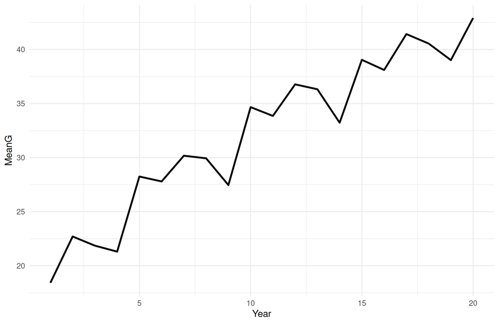

```r
ggplot() +
  geom_line(data = results_Bn, aes(x = year, y = MeanG), size = 1) +
  labs(x = "Year", y = "MeanG", color = " ") +
  theme_minimal()
```

```r
TrainPop
```

```
## An object of class "Pop"
## Ploidy: 2
## Individuals: 855
## Chromosomes: 10
## Loci: 1000
## Traits: 1
```

```r
#Notice that we have selected the last three years (18, 19 and 20) of trials as our Genomic Selection Training Population
```

Because of the script architecture, when we measure the gains by year, we see the increasing of the genetic values as a zig zag. But this is ok, it is just the code structure.

## 7 Comparing Conventional and Genomic Selection

Before comparing the two breeding strategies, the structure of each pipeline is shown below.

### 7.1 Conventional Breeding Pipeline Design

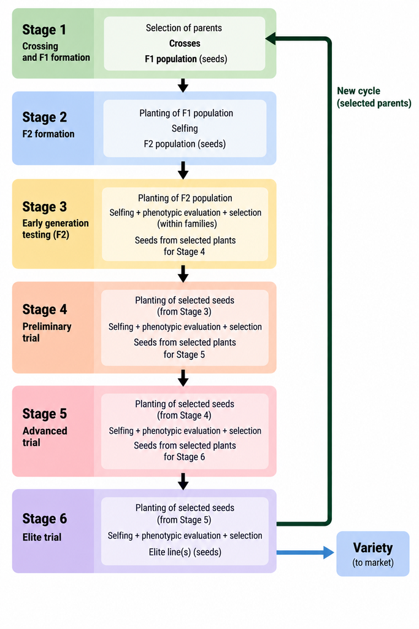

### 7.2 Genomic Selection Pipeline Design

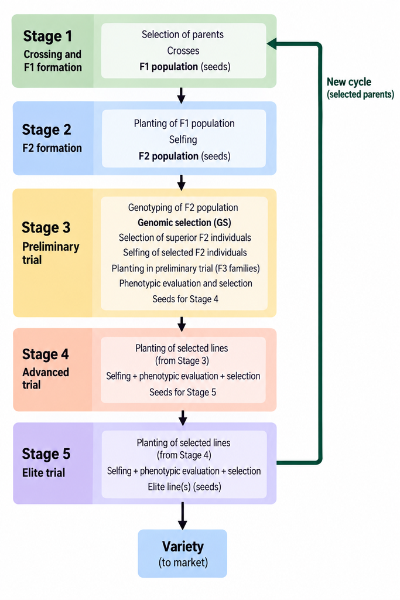

Now that we have done the Burn-In, we have our breeding population, that has passed through selections and has a genetic struture similar as real breeding populations. Now we can use this population as a starting point to do our comparisons.

```r
#Here we are saving the starting population, because this objects will change during the conventional pipeline.

Parents1 = Parents
Variety1 = Variety
EliteTrial1 = EliteTrial
AdvancTrial1 = AdvancTrial
PrelimTrial1 = PrelimTrial
F2pop1 = F2pop
F1pop1 = F1pop


TrainPop1 = TrainPop # Saving the first training population for the Genomic Selection pipeline
```

### 7.3 Conventional Breeding Pipeline

#Conventional pipeline

```r
 years = 20 #20 years of conventional lines breeding program

results_Pheno = data.frame(
  year = integer(),
  MeanG = numeric(),
  VarG  = numeric()
)

for (year in 1:years){

# Stage 6
  Variety = selectInd(EliteTrial, nInd = 1, use = "pheno")
  Parents = EliteTrial

# Stage 5
  EliteTrial  = selectInd(AdvancTrial, nInd = 10, use = "pheno")
  EliteTrial = self(EliteTrial, nProgeny = 1)
  EliteTrial = setPheno(EliteTrial, H2 = 0.8)


# Stage 4
  AdvancTrial = selectInd(PrelimTrial, nInd = 50, use = "pheno")
  AdvancTrial = self(AdvancTrial, nProgeny = 1)
  AdvancTrial = setPheno(AdvancTrial, H2 = 0.6)

# Stage 3
  PrelimTrial = selectWithinFam(rowStage, nInd = 5, use = "pheno")
  PrelimTrial = self(PrelimTrial, nProgeny = 1)
  PrelimTrial = setPheno(PrelimTrial, H2 = 0.4)

# Stage 2
  F2pop = self(pop = F1pop, nProgeny = 10)
  rowStage = setPheno(pop = F2pop, H2 = 0.05)

  cat("Pheno accuracy: ", cor(rowStage@gv, rowStage@pheno), "\n")

# Stage 1
  F1pop = randCross(pop = Parents, nCrosses = 45, nProgeny = 20)

cat("Genetic mean : ", meanG(EliteTrial), "\n")
cat("Genetic variance : ", varG(EliteTrial), "\n")

  results_Pheno = rbind(results_Pheno, data.frame(
    year = year,
    MeanG = meanG(EliteTrial),
    VarG  = varG(EliteTrial),
    acc = cor(rowStage@gv, rowStage@pheno)[1,1]))
}
```

```
## Pheno accuracy:  0.2018413
## Genetic mean :  42.59595
## Genetic variance :  6.304129
## Pheno accuracy:  0.1267042
## Genetic mean :  43.09852
## Genetic variance :  0.918194
## Pheno accuracy:  0.1483943
## Genetic mean :  43.96893
## Genetic variance :  2.469875
## Pheno accuracy:  0.0980985
## Genetic mean :  43.10019
## Genetic variance :  2.890694
## Pheno accuracy:  0.1315666
## Genetic mean :  45.67698
## Genetic variance :  3.378858
## Pheno accuracy:  0.1091159
## Genetic mean :  44.90676
## Genetic variance :  2.730161
## Pheno accuracy:  0.1417761
## Genetic mean :  44.96014
## Genetic variance :  1.267331
## Pheno accuracy:  0.09758325
## Genetic mean :  46.67714
## Genetic variance :  2.591892
## Pheno accuracy:  0.092797
## Genetic mean :  44.72537
## Genetic variance :  1.175979
## Pheno accuracy:  0.1242575
## Genetic mean :  48.11998
## Genetic variance :  0.6386417
## Pheno accuracy:  0.05286133
## Genetic mean :  46.79144
## Genetic variance :  2.161707
## Pheno accuracy:  0.07781879
## Genetic mean :  46.1299
## Genetic variance :  0.9669747
## Pheno accuracy:  0.1003966
## Genetic mean :  48.99492
## Genetic variance :  1.08201
## Pheno accuracy:  0.09562571
## Genetic mean :  45.15503
## Genetic variance :  1.361641
## Pheno accuracy:  0.09007443
## Genetic mean :  49.33602
## Genetic variance :  1.731149
## Pheno accuracy:  0.05494153
## Genetic mean :  47.90561
## Genetic variance :  0.4437262
## Pheno accuracy:  0.08680393
## Genetic mean :  47.26942
## Genetic variance :  0.4988657
## Pheno accuracy:  0.04121691
## Genetic mean :  50.03589
## Genetic variance :  0.4505636
## Pheno accuracy:  0.07168618
## Genetic mean :  46.04308
## Genetic variance :  0.7433875
## Pheno accuracy:  0.05765497
## Genetic mean :  50.54357
## Genetic variance :  1.874907
```

### 7.4 Genomic Selection Pipeline

```r
 years = 20 #20 years of Genomic Selection lines Breeding Program

#Recovering original population, because this objects were edited during the conventional pipeline

Parents = Parents1
Variety = Variety1
EliteTrial = EliteTrial1
AdvancTrial = AdvancTrial1
PrelimTrial = PrelimTrial1
F2pop = F2pop1
F1pop = F1pop1

TrainPop = TrainPop1

results_GS= data.frame(
  year = integer(),
  MeanG = numeric(),
  VarG  = numeric()
)

for (year in 1:years){

  GS.model = RRBLUP(TrainPop, use = "pheno")

# Stage 5
  Variety = selectInd(EliteTrial, nInd = 1, use = "pheno")
  Parents = EliteTrial

# Stage 4
  EliteTrial  = selectInd(AdvancTrial, nInd = 10, use = "pheno")
  EliteTrial = self(EliteTrial, nProgeny = 1)
  EliteTrial = setPheno(EliteTrial, H2 = 0.8)

# Stage 3
  AdvancTrial = selectInd(PrelimTrial, nInd = 50, use = "pheno")
  AdvancTrial = self(AdvancTrial, nProgeny = 1)
  AdvancTrial = setPheno(AdvancTrial, H2 = 0.6)

# Stage 2
  F2pop = self(pop = F1pop, nProgeny = 10)
  F2pop = setEBV(pop = F2pop, GS.model) # We are applying GS on this stage
  #Notice we don't have rowStage anymore,
  #because there is no need for phenotyping. Therefore we remove one stage e save one year.

  cat("GS accuracy: ", cor(F2pop@gv, F2pop@ebv), "\n")

  PrelimTrial = selectWithinFam(F2pop, nInd = 5, use = "ebv")
  PrelimTrial = self(PrelimTrial, nProgeny = 1)
  PrelimTrial = setPheno(PrelimTrial, H2 = 0.4)

  # Saving the training population for the next Genomic Selection pipeline
  TrainPop = c(TrainPop[-((length(TrainPop) - c(PrelimTrial, AdvancTrial, EliteTrial)@nInd + 1):length(TrainPop))],
               PrelimTrial, AdvancTrial, EliteTrial)

# Stage 1
  F1pop = randCross(pop = Parents, nCrosses = 45, nProgeny = 20)

  cat("Genetic mean : ", meanG(EliteTrial), "\n")
  cat("Genetic variance : ", varG(EliteTrial), "\n")

  results_GS = rbind(results_GS, data.frame(
    year = year,
    MeanG = meanG(EliteTrial),
    VarG  = varG(EliteTrial),
    acc = cor(F2pop@gv, F2pop@ebv)[1, 1]))
}
```

```
## GS accuracy:  0.7710255
## Genetic mean :  42.71022
## Genetic variance :  6.505575
## GS accuracy:  0.4746385
## Genetic mean :  43.78439
## Genetic variance :  1.592094
## GS accuracy:  0.7294933
## Genetic mean :  43.8181
## Genetic variance :  1.254875
## GS accuracy:  0.1555096
## Genetic mean :  47.40545
## Genetic variance :  3.333997
## GS accuracy:  0.06621812
## Genetic mean :  45.93352
## Genetic variance :  1.319983
## GS accuracy:  0.6334203
## Genetic mean :  45.95129
## Genetic variance :  1.816061
## GS accuracy:  0.3040505
## Genetic mean :  45.04906
## Genetic variance :  0.7309758
## GS accuracy:  0.2009609
## Genetic mean :  49.87524
## Genetic variance :  2.575699
## GS accuracy:  0.1237936
## Genetic mean :  46.79999
## Genetic variance :  0.5880282
## GS accuracy:  0.4996033
## Genetic mean :  47.71019
## Genetic variance :  1.670708
## GS accuracy:  0.3781381
## Genetic mean :  45.72743
## Genetic variance :  0.6139146
## GS accuracy:  0.2301075
## Genetic mean :  51.97587
## Genetic variance :  0.7773891
## GS accuracy:  0.05130168
## Genetic mean :  47.4856
## Genetic variance :  0.7931363
## GS accuracy:  0.0871312
## Genetic mean :  48.61482
## Genetic variance :  1.081404
## GS accuracy:  0.2040213
## Genetic mean :  46.50119
## Genetic variance :  0.3488818
## GS accuracy:  -0.0961288
## Genetic mean :  52.79298
## Genetic variance :  1.118355
## GS accuracy:  0.2228609
## Genetic mean :  48.0083
## Genetic variance :  0.7143665
## GS accuracy:  0.09336542
## Genetic mean :  48.9127
## Genetic variance :  0.2464929
## GS accuracy:  -0.07131434
## Genetic mean :  47.35048
## Genetic variance :  0.6961895
## GS accuracy:  -0.1775789
## Genetic mean :  53.36266
## Genetic variance :  0.6349384
```

```r
#Inserting initial parents information

row_0 = data.frame(
  year = 0,
  MeanG = meanG(Parents1),
  Trait1 = varG(Parents1),
  acc = NA
)


results_Pheno    = rbind(row_0, results_Pheno)
results_GS = rbind(row_0, results_GS)
```

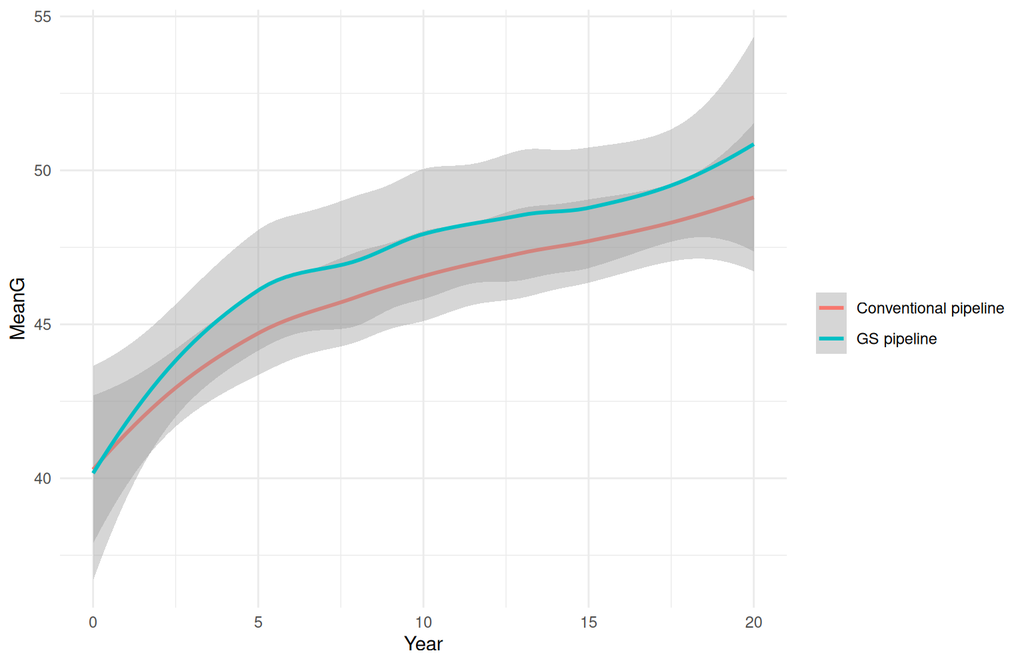

```r
# Plotting results
library(ggplot2)

ggplot() +
  geom_smooth(data = results_Pheno, aes(x = year, y = MeanG, color = "Conventional pipeline"), size = 1) +
  geom_smooth(data = results_GS, aes(x = year, y = MeanG, color = "GS pipeline"), size = 1) +
  labs(x = "Year", y = "MeanG", color = " ") +
  theme_minimal()
```

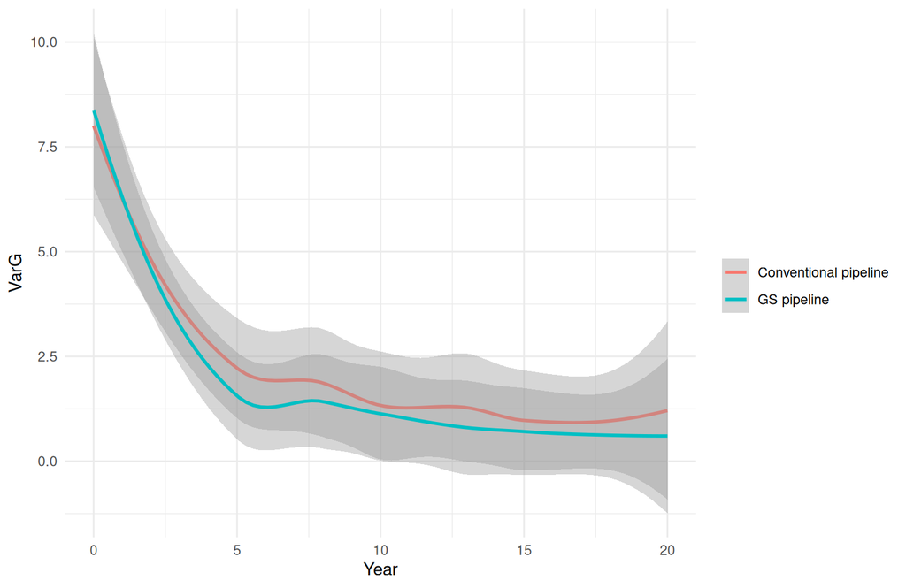

```r
ggplot() +
  geom_smooth(data = results_Pheno, aes(x = year, y = Trait1, color = "Conventional pipeline"), size = 1) +
  geom_smooth(data = results_GS, aes(x = year, y = Trait1, color = "GS pipeline"), size = 1) +
  labs(x = "Year", y = "VarG", color = " ") +
  theme_minimal()
```

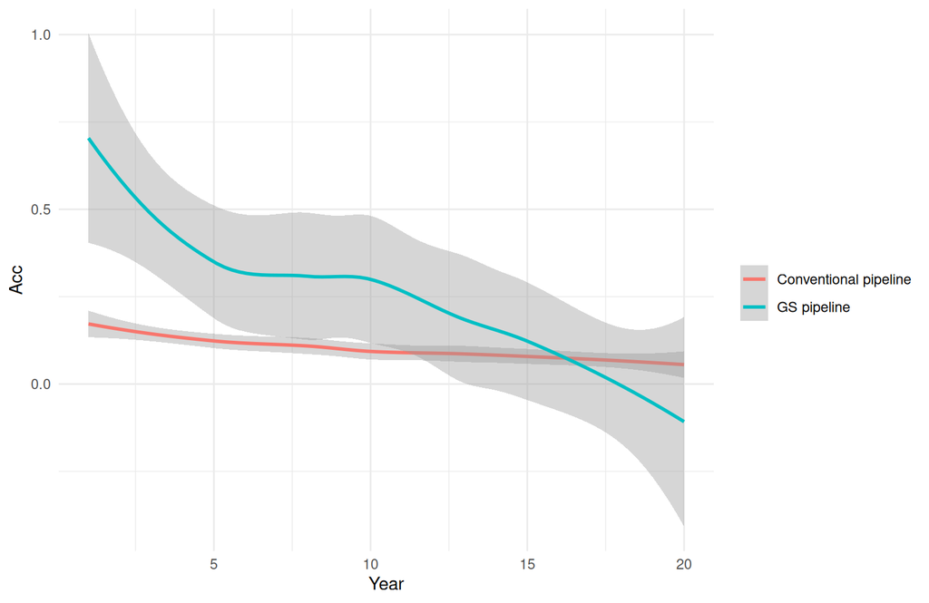

```r
ggplot() +
  geom_smooth(data = results_Pheno, aes(x = year, y = acc, color = "Conventional pipeline"), size = 1) +
  geom_smooth(data = results_GS, aes(x = year, y = acc, color = "GS pipeline"), size = 1) +
  labs(x = "Year", y = "Acc", color = " ") +
  theme_minimal()
```

### 7.5 Repeated Replications

It is important to highlight that, for more consistent results, we need to run several replications to obtain more reliable estimates.

## 8 Clonal Breeding Program

### 8.1 Founder Population and Genetic Architecture

```r
# Founder genome
founderGenomes = runMacs(nInd = 10, # Number of individuals that compose the base genome
                         nChr = 10, # Number of chromosome pairs of the target species
                         segSites = 100, # number of segregation sites
                         species = "GENERIC", # Available presets: MAIZE, WHEAT, CATTLE, GENERIC
                         ploidy = 4) # Setting the ploidy


# Global simulation parameters from founder genomes.
SP = SimParam$new(founderGenomes)

# Additive trait
SP$addTraitAD(nQtlPerChr = 15, # Number of QTL per chromosome
             mean = 10,       # Trait mean
             var = 5,       # Trait variance
             meanDD = 5)       # This time we are using Dominance effects

# Creating individuals/population
basePop = newPop(founderGenomes)

pullQtlGeno(basePop)
```

```
##    1_4 1_17 1_30 1_32 1_57 1_60 1_63 1_74 1_85 1_86 1_89 1_90 1_93 1_95 1_99
## 1    2    0    0    1    2    4    2    0    4    0    0    2    0    0    2
## 2    3    1    2    0    3    3    3    1    4    2    0    0    1    1    1
## 3    2    0    0    0    0    4    0    3    3    2    1    0    1    0    3
## 4    3    0    1    0    0    4    1    0    2    1    1    0    1    0    2
## 5    4    0    1    1    1    3    1    0    1    0    1    0    0    0    3
## 6    1    0    0    2    3    3    1    1    4    0    0    0    1    0    3
## 7    2    0    0    1    0    4    3    2    4    0    0    2    0    0    0
## 8    2    0    1    1    1    3    2    1    2    2    0    0    0    0    3
## 9    1    0    1    0    1    2    2    0    2    0    1    0    2    1    0
## 10   2    0    1    0    2    4    2    0    3    1    0    1    0    0    4
##    2_4 2_15 2_18 2_25 2_38 2_46 2_51 2_61 2_68 2_73 2_80 2_83 2_86 2_93 2_95
## 1    4    1    4    0    3    2    4    4    2    2    1    2    2    3    2
## 2    4    0    2    1    3    1    4    4    1    3    2    2    3    3    2
## 3    4    0    3    2    2    1    3    3    1    3    3    1    3    4    2
```

[output cut: 106 more lines]

### 8.2 Filling the Clonal Pipeline

```r
#Filling the pipeline

Parents = basePop
trials = 3
for(trial in 1:trials){
  cat("  FillPipeline stage:",trial,"of 3\n")
  if(trial<3){
    # Stage 1
  C1pop = randCross(pop = Parents, nCrosses = 40, nProgeny = 200)
  }
  if(trial<2){
    # Stage 2
  C1pop = setPheno(pop = C1pop, H2 = 0.2)
  C2pop = selectInd(pop = C1pop, nInd = 100, use = "pheno")

        }
  if(trial<1){
    # Stage 3

  C2pop = setPheno(pop = C2pop, H2 = 0.4)
  C2pop = selectInd(pop = C2pop, nInd = 10, use = "pheno")
  Variety = selectInd(C2pop, nInd = 1, use = "pheno")

  }
}
```

```
##   FillPipeline stage: 1 of 3
##   FillPipeline stage: 2 of 3
##   FillPipeline stage: 3 of 3
```

### 8.3 Clonal Program Burn-in

```r
#Advancing 20 years of conventional lines breeding program

nBurnin = 20

results_Bn = data.frame(
  nBurnin = integer(),
  MeanG = numeric(),
  VarG  = numeric()
)

for (year in 1:nBurnin){

  # Stage 3
  C2pop = setPheno(pop = C2pop, H2 = 0.4)
  Variety = selectInd(C2pop, nInd = 1, use = "pheno")
  Parents = selectInd(pop = C2pop, nInd = 10, use = "pheno")

  # Stage 2
  C1pop = setPheno(pop = C1pop, H2 = 0.2)
  C2pop = selectInd(pop = C1pop, nInd = 80, use = "pheno")

  # Stage 1
  C1pop = randCross(pop = Parents, nCrosses = 40, nProgeny = 200)

  cat("Genetic mean : ", meanG(C2pop), "\n")
  cat("Genetic variance : ", varG(C2pop), "\n")

  results_Bn = rbind(results_Bn, data.frame(
    year = year,
    MeanG = meanG(C2pop),
    VarG  = varG(C2pop)))

}
```

```
## Genetic mean :  13.22308
## Genetic variance :  3.337768
## Genetic mean :  15.41359
## Genetic variance :  3.835639
## Genetic mean :  15.23023
## Genetic variance :  3.715632
## Genetic mean :  17.26956
## Genetic variance :  2.992353
## Genetic mean :  15.80948
## Genetic variance :  3.410521
## Genetic mean :  18.01087
## Genetic variance :  3.12059
## Genetic mean :  16.73357
## Genetic variance :  3.348834
## Genetic mean :  18.81923
## Genetic variance :  3.762903
## Genetic mean :  17.96735
## Genetic variance :  3.527985
## Genetic mean :  20.32725
## Genetic variance :  3.3852
## Genetic mean :  18.58144
## Genetic variance :  3.450436
## Genetic mean :  21.27212
## Genetic variance :  2.002399
## Genetic mean :  19.38414
## Genetic variance :  2.990292
## Genetic mean :  21.29415
## Genetic variance :  3.588508
## Genetic mean :  19.82829
## Genetic variance :  2.498025
## Genetic mean :  21.7614
## Genetic variance :  3.556416
## Genetic mean :  20.15324
## Genetic variance :  2.470541
## Genetic mean :  22.45042
## Genetic variance :  2.491219
## Genetic mean :  19.84232
## Genetic variance :  3.468753
## Genetic mean :  22.09406
## Genetic variance :  2.990757
```

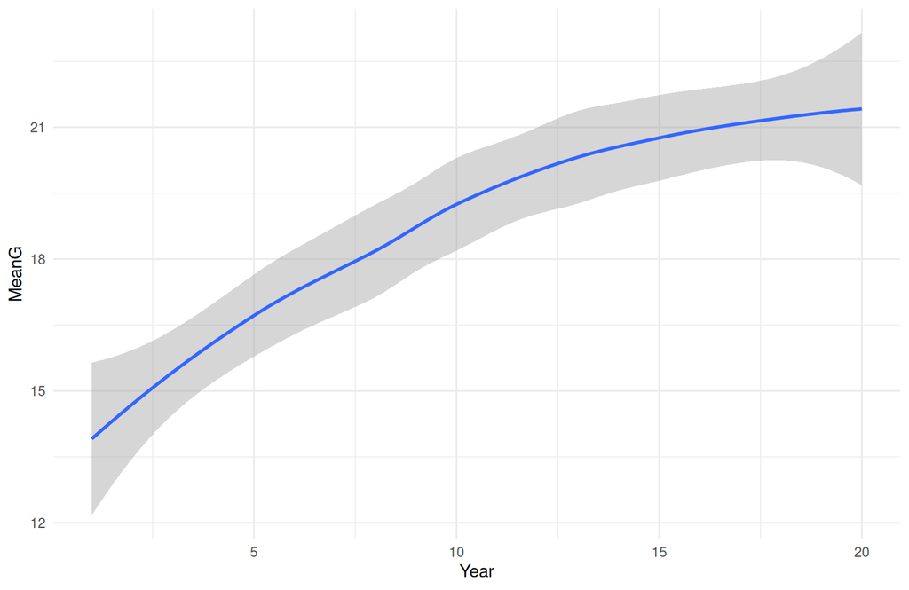

```r
ggplot() +
  geom_smooth(data = results_Bn, aes(x = year, y = MeanG), size = 1) +
  labs(x = "Year", y = "MeanG", color = " ") +
  theme_minimal()
```

Now that we have the starting population, we can compare different breeding programs. Let’s imagine that we want to evaluate whether it is better to select within families or to select directly among individuals.

### 8.4 Two Clonal Breeding Pipeline

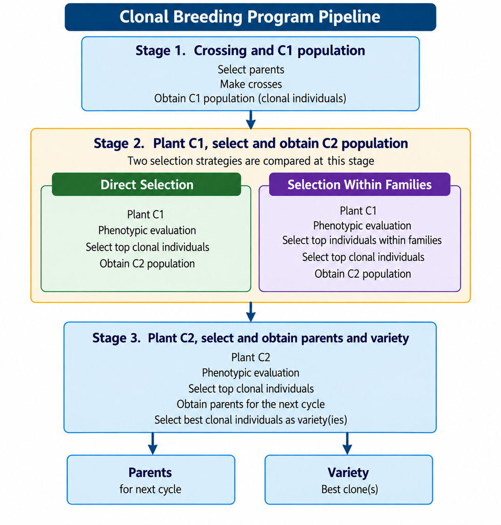

```r
#Saving the starting population.

Parents1 = Parents
Variety1 = Variety
C2pop1 = C2pop
C1pop1 = C2pop
```

#### 8.4.1 Direct Selection of Individuals

The first program is going to make direct selection of individuals in C1:

```r
#Advancing a 20-year clonal breeding program by selecting individuals directly in C1.
years = 20

results_Ind = data.frame(
  year = integer(),
  MeanG = numeric(),
  VarG  = numeric()
)

for (year in 1:years){

  # Stage 3
  C2pop = setPheno(pop = C2pop, H2 = 0.4)
  Variety = selectInd(C2pop, nInd = 1, use = "pheno")
  Parents = selectInd(pop = C2pop, nInd = 10, use = "pheno")

  # Stage 2
  C1pop = setPheno(pop = C1pop, H2 = 0.2)
  C2pop = selectInd(pop = C1pop, nInd = 80, use = "pheno")

  # Stage 1
  C1pop = randCross(pop = Parents, nCrosses = 40, nProgeny = 200)

  cat("Genetic mean : ", meanG(C2pop), "\n")
  cat("Genetic variance : ", varG(C2pop), "\n")

  results_Ind = rbind(results_Ind, data.frame(
    year = year,
    MeanG = meanG(C2pop),
    VarG  = varG(C2pop)))

}
```

```
## Genetic mean :  20.62909
## Genetic variance :  3.543982
## Genetic mean :  22.55537
## Genetic variance :  2.126443
## Genetic mean :  21.72996
## Genetic variance :  3.282968
## Genetic mean :  22.7042
## Genetic variance :  2.622114
## Genetic mean :  22.23561
## Genetic variance :  3.699262
## Genetic mean :  22.90017
## Genetic variance :  3.174473
## Genetic mean :  22.0712
## Genetic variance :  2.267867
## Genetic mean :  23.44592
## Genetic variance :  2.509523
## Genetic mean :  21.69917
## Genetic variance :  2.604308
## Genetic mean :  23.07989
## Genetic variance :  2.731971
## Genetic mean :  21.76908
## Genetic variance :  2.307829
## Genetic mean :  23.0043
## Genetic variance :  3.77047
## Genetic mean :  21.61663
## Genetic variance :  2.470674
## Genetic mean :  23.36128
## Genetic variance :  2.798653
## Genetic mean :  21.16483
## Genetic variance :  2.994398
## Genetic mean :  23.679
## Genetic variance :  2.211674
## Genetic mean :  21.58577
## Genetic variance :  2.647235
## Genetic mean :  22.89882
## Genetic variance :  2.662552
## Genetic mean :  21.75653
## Genetic variance :  2.545471
## Genetic mean :  23.39914
## Genetic variance :  2.499707
```

#### 8.4.2 Selection Within Families

The second program is going to make selection of individuals within families in C1:

```r
#Advancing a 20-year clonal breeding program by selecting individuals within families in C1.

years = 20

#Recovering original population

Parents = Parents1
Variety = Variety1
C2pop = C2pop1
C1pop = C2pop1

results_Fam = data.frame(
  year = integer(),
  MeanG = numeric(),
  VarG  = numeric()
)

for (year in 1:years){

  # Stage 3
  C2pop = setPheno(pop = C2pop, H2 = 0.4)
  Variety = selectInd(C2pop, nInd = 1, use = "pheno")
  Parents = selectInd(pop = C2pop, nInd = 10, use = "pheno")

  # Stage 2
  C1pop = setPheno(pop = C1pop, H2 = 0.2)
  C2pop = selectWithinFam(pop = C1pop, nInd = 5, use = "pheno") #Selecting within families
  C2pop = selectInd(pop = C2pop, nInd = 80, use = "pheno")

  # Stage 1
  C1pop = randCross(pop = Parents, nCrosses = 40, nProgeny = 200)

  cat("Genetic mean : ", meanG(C2pop), "\n")
  cat("Genetic variance : ", varG(C2pop), "\n")

  results_Fam = rbind(results_Fam, data.frame(
    year = year,
    MeanG = meanG(C2pop),
    VarG  = varG(C2pop)))

}
```

```
## Genetic mean :  22.09406
## Genetic variance :  2.990757
## Genetic mean :  22.41724
## Genetic variance :  3.526346
## Genetic mean :  22.06983
## Genetic variance :  2.4143
## Genetic mean :  23.00459
## Genetic variance :  2.778991
## Genetic mean :  22.3645
## Genetic variance :  2.370058
## Genetic mean :  22.74858
## Genetic variance :  2.774479
## Genetic mean :  22.47538
## Genetic variance :  2.566926
## Genetic mean :  23.28674
## Genetic variance :  2.114192
## Genetic mean :  22.63728
## Genetic variance :  3.297779
## Genetic mean :  23.08546
## Genetic variance :  4.089869
## Genetic mean :  22.45738
## Genetic variance :  2.931525
## Genetic mean :  23.10363
## Genetic variance :  2.177342
## Genetic mean :  22.86334
## Genetic variance :  3.123743
## Genetic mean :  23.47023
## Genetic variance :  2.579087
## Genetic mean :  22.70394
## Genetic variance :  2.218602
## Genetic mean :  23.31577
## Genetic variance :  2.742758
## Genetic mean :  22.75898
## Genetic variance :  2.605509
## Genetic mean :  22.89821
## Genetic variance :  2.986181
## Genetic mean :  22.97739
## Genetic variance :  3.222653
## Genetic mean :  23.14378
## Genetic variance :  2.932499
```

```r
#Inserting initial parents information

row_0 = data.frame(
  year = 0,
  MeanG = meanG(Parents1),
  Trait1 = varG(Parents1)
)


results_Ind    = rbind(row_0, results_Ind)
results_Fam = rbind(row_0, results_Fam)
```

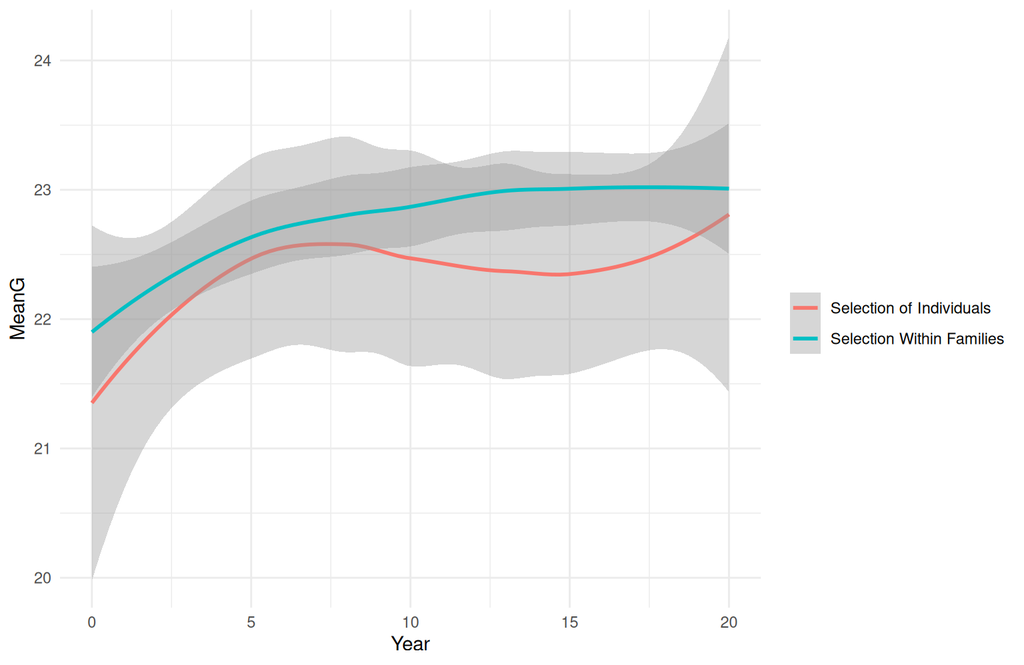

```r
ggplot() +
  geom_smooth(data = results_Ind, aes(x = year, y = MeanG, color = "Selection of Individuals"), size = 1) +
  geom_smooth(data = results_Fam, aes(x = year, y = MeanG, color = "Selection Within Families"), size = 1) +
  labs(x = "Year", y = "MeanG", color = " ") +
  theme_minimal()
```

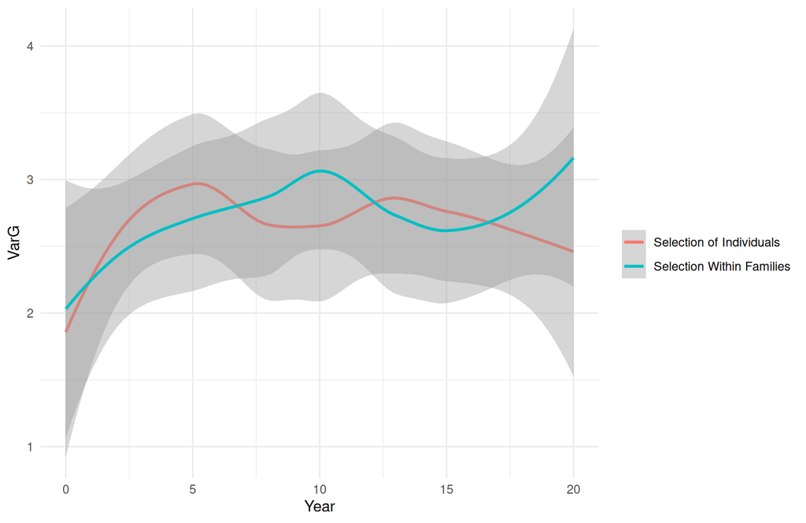

```r
ggplot() +
  geom_smooth(data = results_Ind, aes(x = year, y = Trait1, color = "Selection of Individuals"), size = 1) +
  geom_smooth(data = results_Fam, aes(x = year, y = Trait1, color = "Selection Within Families"), size = 1) +
  labs(x = "Year", y = "VarG", color = " ") +
  theme_minimal()
```

For more details: For a practical introduction to breeding program simulation with AlphaSimR, see Bančič et al. (2024), Plant breeding simulations with AlphaSimR. The paper provides a systematic approach to designing breeding program simulations and includes examples of self-pollinated, clonal, and hybrid breeding programs. For details on individual AlphaSimR functions, arguments, and examples, consult the official AlphaSimR documentation.